# cnn_cifar_keras

```python
import numpy as np
from keras.models import Sequential
from keras.layers import Dense,Flatten,Conv2D,MaxPooling2D
from keras.datasets import cifar10
from keras.utils import to_categorical
from keras.optimizers import Adam
from keras.callbacks import ModelCheckpoint
import matplotlib.pyplot as plt
```

```python
(x_train,y_train),(x_test,y_test)=cifar10.load_data()
```

```
Downloading data from https://www.cs.toronto.edu/~kriz/cifar-10-python.tar.gz
170498071/170498071 ━━━━━━━━━━━━━━━━━━━━ 4s 0us/step
```

```python
y_train_cat=to_categorical(y_train)
y_test_cat=to_categorical(y_test)
```

```python
model=Sequential()
model.add(Conv2D(32,(3,3),activation='relu'))
model.add(MaxPooling2D((2,2)))
model.add(Conv2D(32,(3,3),activation='relu'))
model.add(MaxPooling2D((2,2)))
model.add(Flatten())
model.add(Dense(1024,activation='relu'))
model.add(Dense(512,activation='relu'))
model.add(Dense(256,activation='relu'))
model.add(Dense(128,activation='relu'))
model.add(Dense(64,activation='relu'))
model.add(Dense(10,activation='softmax'))
```

```python
model.compile(optimizer=Adam(learning_rate=0.0001),loss='categorical_crossentropy',metrics=['accuracy'])
```

```python
cb=ModelCheckpoint('best_model.h5',monitor='val_loss',mode='min',save_best_only=True)
```

```python
# Train the model
result = model.fit(x_train, y_train_cat,
                  epochs=50,
                  batch_size=64,
                  validation_split=0.2,
                  callbacks=[cb],
                  verbose=1)

# Evaluate the model
loss, test_accuracy = model.evaluate(x_test, y_test_cat, verbose=0)
print(f"\n🎯 Final Test Results:")
print(f"Test Loss: {loss:.4f}")
print(f"Test Accuracy: {test_accuracy:.4f} ({test_accuracy*100:.2f}%)")
```

```
619/625 ━━━━━━━━━━━━━━━━━━━━ 0s 4ms/step - accuracy: 0.2914 - loss: 2.2670
```

[output not shown]

```
625/625 ━━━━━━━━━━━━━━━━━━━━ 12s 8ms/step - accuracy: 0.2923 - loss: 2.2621 - val_accuracy: 0.4621 - val_loss: 1.5331
623/625 ━━━━━━━━━━━━━━━━━━━━ 0s 4ms/step - accuracy: 0.5032 - loss: 1.4119
```

[output not shown]

```
625/625 ━━━━━━━━━━━━━━━━━━━━ 3s 5ms/step - accuracy: 0.5033 - loss: 1.4118 - val_accuracy: 0.5235 - val_loss: 1.3937
616/625 ━━━━━━━━━━━━━━━━━━━━ 0s 4ms/step - accuracy: 0.5681 - loss: 1.2231
```

[output not shown]

```
625/625 ━━━━━━━━━━━━━━━━━━━━ 5s 5ms/step - accuracy: 0.5682 - loss: 1.2228 - val_accuracy: 0.5641 - val_loss: 1.2452
625/625 ━━━━━━━━━━━━━━━━━━━━ 5s 5ms/step - accuracy: 0.6360 - loss: 1.0492 - val_accuracy: 0.5672 - val_loss: 1.2653
622/625 ━━━━━━━━━━━━━━━━━━━━ 0s 4ms/step - accuracy: 0.6870 - loss: 0.9107
```

[output not shown]

```
625/625 ━━━━━━━━━━━━━━━━━━━━ 5s 5ms/step - accuracy: 0.6870 - loss: 0.9107 - val_accuracy: 0.5970 - val_loss: 1.1744
625/625 ━━━━━━━━━━━━━━━━━━━━ 5s 5ms/step - accuracy: 0.7336 - loss: 0.7740 - val_accuracy: 0.6093 - val_loss: 1.1770
615/625 ━━━━━━━━━━━━━━━━━━━━ 0s 4ms/step - accuracy: 0.7793 - loss: 0.6496
```

[output not shown]

```
625/625 ━━━━━━━━━━━━━━━━━━━━ 5s 5ms/step - accuracy: 0.7792 - loss: 0.6497 - val_accuracy: 0.6238 - val_loss: 1.1656
625/625 ━━━━━━━━━━━━━━━━━━━━ 5s 5ms/step - accuracy: 0.8211 - loss: 0.5352 - val_accuracy: 0.6351 - val_loss: 1.1939
625/625 ━━━━━━━━━━━━━━━━━━━━ 3s 5ms/step - accuracy: 0.8699 - loss: 0.4049 - val_accuracy: 0.6375 - val_loss: 1.2468
625/625 ━━━━━━━━━━━━━━━━━━━━ 3s 4ms/step - accuracy: 0.8986 - loss: 0.3139 - val_accuracy: 0.6356 - val_loss: 1.3506
625/625 ━━━━━━━━━━━━━━━━━━━━ 3s 5ms/step - accuracy: 0.9293 - loss: 0.2356 - val_accuracy: 0.6254 - val_loss: 1.4936
625/625 ━━━━━━━━━━━━━━━━━━━━ 3s 5ms/step - accuracy: 0.9469 - loss: 0.1714 - val_accuracy: 0.6306 - val_loss: 1.5671
625/625 ━━━━━━━━━━━━━━━━━━━━ 3s 5ms/step - accuracy: 0.9681 - loss: 0.1156 - val_accuracy: 0.6332 - val_loss: 1.6739
625/625 ━━━━━━━━━━━━━━━━━━━━ 5s 4ms/step - accuracy: 0.9745 - loss: 0.0913 - val_accuracy: 0.6328 - val_loss: 1.8389
625/625 ━━━━━━━━━━━━━━━━━━━━ 5s 5ms/step - accuracy: 0.9747 - loss: 0.0880 - val_accuracy: 0.6286 - val_loss: 1.9221
625/625 ━━━━━━━━━━━━━━━━━━━━ 3s 5ms/step - accuracy: 0.9731 - loss: 0.0838 - val_accuracy: 0.6282 - val_loss: 1.9448
625/625 ━━━━━━━━━━━━━━━━━━━━ 3s 4ms/step - accuracy: 0.9811 - loss: 0.0640 - val_accuracy: 0.6365 - val_loss: 1.9858
625/625 ━━━━━━━━━━━━━━━━━━━━ 5s 4ms/step - accuracy: 0.9857 - loss: 0.0521 - val_accuracy: 0.6282 - val_loss: 2.0530
625/625 ━━━━━━━━━━━━━━━━━━━━ 3s 5ms/step - accuracy: 0.9799 - loss: 0.0625 - val_accuracy: 0.6342 - val_loss: 2.2062
625/625 ━━━━━━━━━━━━━━━━━━━━ 5s 5ms/step - accuracy: 0.9890 - loss: 0.0375 - val_accuracy: 0.6196 - val_loss: 2.2686
625/625 ━━━━━━━━━━━━━━━━━━━━ 5s 5ms/step - accuracy: 0.9798 - loss: 0.0633 - val_accuracy: 0.6289 - val_loss: 2.2297
625/625 ━━━━━━━━━━━━━━━━━━━━ 5s 5ms/step - accuracy: 0.9869 - loss: 0.0419 - val_accuracy: 0.6365 - val_loss: 2.3330
625/625 ━━━━━━━━━━━━━━━━━━━━ 4s 4ms/step - accuracy: 0.9833 - loss: 0.0513 - val_accuracy: 0.6373 - val_loss: 2.2630
625/625 ━━━━━━━━━━━━━━━━━━━━ 3s 5ms/step - accuracy: 0.9900 - loss: 0.0344 - val_accuracy: 0.6367 - val_loss: 2.4451
625/625 ━━━━━━━━━━━━━━━━━━━━ 3s 4ms/step - accuracy: 0.9897 - loss: 0.0352 - val_accuracy: 0.6198 - val_loss: 2.3275
625/625 ━━━━━━━━━━━━━━━━━━━━ 3s 5ms/step - accuracy: 0.9855 - loss: 0.0418 - val_accuracy: 0.6354 - val_loss: 2.3626
625/625 ━━━━━━━━━━━━━━━━━━━━ 3s 4ms/step - accuracy: 0.9900 - loss: 0.0322 - val_accuracy: 0.6350 - val_loss: 2.4982
625/625 ━━━━━━━━━━━━━━━━━━━━ 5s 5ms/step - accuracy: 0.9846 - loss: 0.0476 - val_accuracy: 0.6386 - val_loss: 2.4603
625/625 ━━━━━━━━━━━━━━━━━━━━ 3s 4ms/step - accuracy: 0.9877 - loss: 0.0365 - val_accuracy: 0.6407 - val_loss: 2.5258
625/625 ━━━━━━━━━━━━━━━━━━━━ 6s 5ms/step - accuracy: 0.9900 - loss: 0.0313 - val_accuracy: 0.6285 - val_loss: 2.5914
625/625 ━━━━━━━━━━━━━━━━━━━━ 3s 5ms/step - accuracy: 0.9849 - loss: 0.0492 - val_accuracy: 0.6282 - val_loss: 2.5942
625/625 ━━━━━━━━━━━━━━━━━━━━ 3s 4ms/step - accuracy: 0.9912 - loss: 0.0298 - val_accuracy: 0.6368 - val_loss: 2.5499
625/625 ━━━━━━━━━━━━━━━━━━━━ 5s 4ms/step - accuracy: 0.9965 - loss: 0.0128 - val_accuracy: 0.6224 - val_loss: 2.8406
625/625 ━━━━━━━━━━━━━━━━━━━━ 3s 6ms/step - accuracy: 0.9852 - loss: 0.0459 - val_accuracy: 0.6337 - val_loss: 2.4711
625/625 ━━━━━━━━━━━━━━━━━━━━ 4s 4ms/step - accuracy: 0.9903 - loss: 0.0288 - val_accuracy: 0.6323 - val_loss: 2.6057
625/625 ━━━━━━━━━━━━━━━━━━━━ 3s 4ms/step - accuracy: 0.9912 - loss: 0.0285 - val_accuracy: 0.6357 - val_loss: 2.6181
625/625 ━━━━━━━━━━━━━━━━━━━━ 3s 5ms/step - accuracy: 0.9909 - loss: 0.0293 - val_accuracy: 0.6327 - val_loss: 2.5646
625/625 ━━━━━━━━━━━━━━━━━━━━ 5s 5ms/step - accuracy: 0.9919 - loss: 0.0249 - val_accuracy: 0.6332 - val_loss: 2.7556
625/625 ━━━━━━━━━━━━━━━━━━━━ 5s 5ms/step - accuracy: 0.9923 - loss: 0.0249 - val_accuracy: 0.6443 - val_loss: 2.5649
625/625 ━━━━━━━━━━━━━━━━━━━━ 5s 5ms/step - accuracy: 0.9910 - loss: 0.0285 - val_accuracy: 0.6345 - val_loss: 2.7114
625/625 ━━━━━━━━━━━━━━━━━━━━ 5s 5ms/step - accuracy: 0.9928 - loss: 0.0228 - val_accuracy: 0.6348 - val_loss: 2.6790
625/625 ━━━━━━━━━━━━━━━━━━━━ 6s 6ms/step - accuracy: 0.9900 - loss: 0.0304 - val_accuracy: 0.6325 - val_loss: 2.7849
625/625 ━━━━━━━━━━━━━━━━━━━━ 3s 5ms/step - accuracy: 0.9932 - loss: 0.0204 - val_accuracy: 0.6215 - val_loss: 2.9406
625/625 ━━━━━━━━━━━━━━━━━━━━ 3s 5ms/step - accuracy: 0.9900 - loss: 0.0305 - val_accuracy: 0.6169 - val_loss: 3.0216
625/625 ━━━━━━━━━━━━━━━━━━━━ 3s 5ms/step - accuracy: 0.9902 - loss: 0.0295 - val_accuracy: 0.6295 - val_loss: 2.8507
625/625 ━━━━━━━━━━━━━━━━━━━━ 3s 5ms/step - accuracy: 0.9931 - loss: 0.0233 - val_accuracy: 0.6333 - val_loss: 2.8338
625/625 ━━━━━━━━━━━━━━━━━━━━ 3s 5ms/step - accuracy: 0.9933 - loss: 0.0198 - val_accuracy: 0.6363 - val_loss: 2.9046
625/625 ━━━━━━━━━━━━━━━━━━━━ 5s 5ms/step - accuracy: 0.9901 - loss: 0.0317 - val_accuracy: 0.6314 - val_loss: 2.9735
625/625 ━━━━━━━━━━━━━━━━━━━━ 5s 4ms/step - accuracy: 0.9927 - loss: 0.0212 - val_accuracy: 0.6384 - val_loss: 2.8515
625/625 ━━━━━━━━━━━━━━━━━━━━ 3s 4ms/step - accuracy: 0.9944 - loss: 0.0175 - val_accuracy: 0.6297 - val_loss: 2.9140

🎯 Final Test Results:
Test Loss: 2.9624
Test Accuracy: 0.6275 (62.75%)
```

```
Sample prediction: cat
```

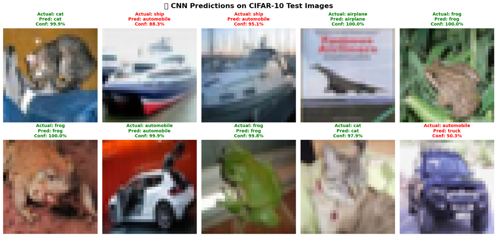

```python
# CIFAR-10 class names
class_names = ['airplane', 'automobile', 'bird', 'cat', 'deer',
               'dog', 'frog', 'horse', 'ship', 'truck']

# Make predictions
predictions = model.predict(x_test, verbose=0)
predict_labels = np.argmax(predictions, axis=1)

print(f"Sample prediction: {class_names[predict_labels[0]]}")

# Enhanced prediction visualization
plt.figure(figsize=(16, 8))

# Show more examples with better layout
n_samples = 10
for i in range(n_samples):
    plt.subplot(2, 5, i + 1)
    plt.imshow(x_test[i])

    actual_class = class_names[y_test[i][0]]
    predicted_class = class_names[predict_labels[i]]
    confidence = predictions[i][predict_labels[i]] * 100

    # Color code: green for correct, red for incorrect
    color = 'green' if actual_class == predicted_class else 'red'

    plt.title(f'Actual: {actual_class}\nPred: {predicted_class}\nConf: {confidence:.1f}%',
              fontsize=10, color=color, weight='bold')
    plt.axis('off')

plt.suptitle('🔍 CNN Predictions on CIFAR-10 Test Images', fontsize=16, fontweight='bold')
plt.tight_layout()
plt.show()
```

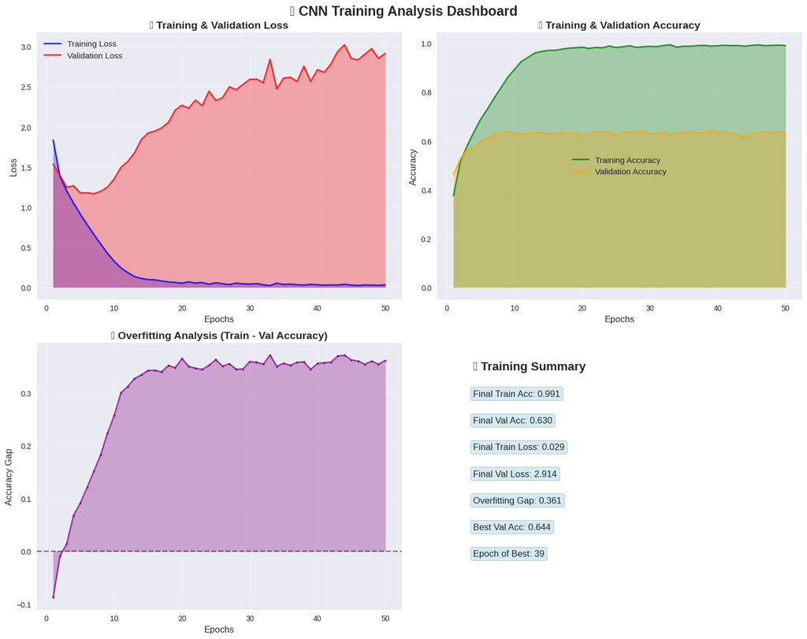

```python
# Enhanced Training History Visualization
plt.style.use('seaborn-v0_8')  # Use a more modern style
fig, ((ax1, ax2), (ax3, ax4)) = plt.subplots(2, 2, figsize=(15, 12))

# Extract training history
epochs = range(1, len(result.history['loss']) + 1)
train_loss = result.history['loss']
val_loss = result.history['val_loss']
train_acc = result.history['accuracy']
val_acc = result.history['val_accuracy']

# 1. Loss Curves with Enhanced Styling
ax1.plot(epochs, train_loss, 'b-', linewidth=2, label='Training Loss', alpha=0.8)
ax1.plot(epochs, val_loss, 'r-', linewidth=2, label='Validation Loss', alpha=0.8)
ax1.fill_between(epochs, train_loss, alpha=0.3, color='blue')
ax1.fill_between(epochs, val_loss, alpha=0.3, color='red')
ax1.set_title('📉 Training & Validation Loss', fontsize=14, fontweight='bold')
ax1.set_xlabel('Epochs', fontsize=12)
ax1.set_ylabel('Loss', fontsize=12)
ax1.legend(fontsize=11)
ax1.grid(True, alpha=0.3)

# 2. Accuracy Curves with Enhanced Styling
ax2.plot(epochs, train_acc, 'g-', linewidth=2, label='Training Accuracy', alpha=0.8)
ax2.plot(epochs, val_acc, 'orange', linewidth=2, label='Validation Accuracy', alpha=0.8)
ax2.fill_between(epochs, train_acc, alpha=0.3, color='green')
ax2.fill_between(epochs, val_acc, alpha=0.3, color='orange')
ax2.set_title('📈 Training & Validation Accuracy', fontsize=14, fontweight='bold')
ax2.set_xlabel('Epochs', fontsize=12)
ax2.set_ylabel('Accuracy', fontsize=12)
ax2.legend(fontsize=11)
ax2.grid(True, alpha=0.3)

# 3. Overfitting Analysis
gap = np.array(train_acc) - np.array(val_acc)
ax3.plot(epochs, gap, 'purple', linewidth=2, marker='o', markersize=3, alpha=0.7)
ax3.fill_between(epochs, gap, alpha=0.3, color='purple')
ax3.axhline(y=0, color='black', linestyle='--', alpha=0.5)
ax3.set_title('🎯 Overfitting Analysis (Train - Val Accuracy)', fontsize=14, fontweight='bold')
ax3.set_xlabel('Epochs', fontsize=12)
ax3.set_ylabel('Accuracy Gap', fontsize=12)
ax3.grid(True, alpha=0.3)

# 4. Learning Rate vs Performance (if available) or Summary Stats
final_train_acc = train_acc[-1]
final_val_acc = val_acc[-1]
final_train_loss = train_loss[-1]
final_val_loss = val_loss[-1]

stats = [
    f'Final Train Acc: {final_train_acc:.3f}',
    f'Final Val Acc: {final_val_acc:.3f}',
    f'Final Train Loss: {final_train_loss:.3f}',
    f'Final Val Loss: {final_val_loss:.3f}',
    f'Overfitting Gap: {final_train_acc - final_val_acc:.3f}',
    f'Best Val Acc: {max(val_acc):.3f}',
    f'Epoch of Best: {np.argmax(val_acc) + 1}'
]

ax4.axis('off')
ax4.text(0.1, 0.9, '📊 Training Summary', fontsize=16, fontweight='bold', transform=ax4.transAxes)
for i, stat in enumerate(stats):
    ax4.text(0.1, 0.8 - i*0.1, stat, fontsize=12, transform=ax4.transAxes,
             bbox=dict(boxstyle="round,pad=0.3", facecolor="lightblue", alpha=0.5))

plt.suptitle('🧠 CNN Training Analysis Dashboard', fontsize=18, fontweight='bold', y=0.98)
plt.tight_layout()
plt.show()
```

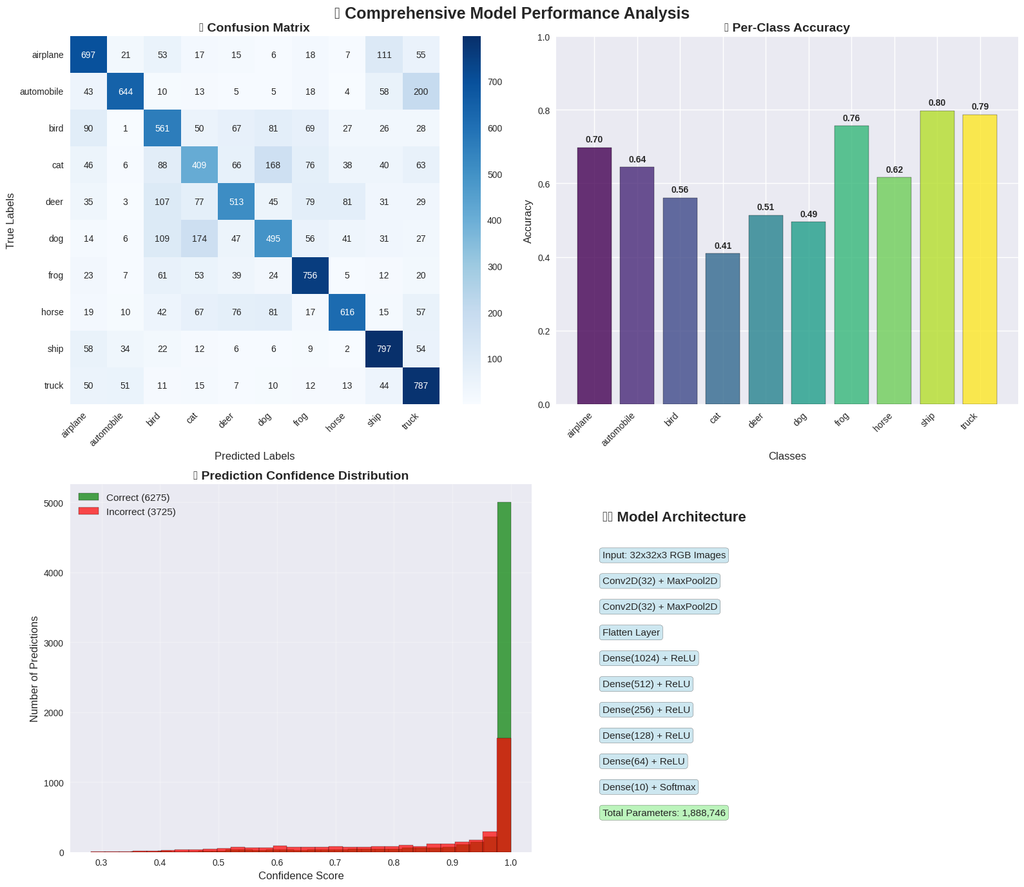

```
============================================================
📋 DETAILED CLASSIFICATION REPORT
============================================================
              precision    recall  f1-score   support

    airplane     0.6484    0.6970    0.6718      1000
  automobile     0.8225    0.6440    0.7224      1000
        bird     0.5273    0.5610    0.5436      1000
         cat     0.4611    0.4090    0.4335      1000
        deer     0.6100    0.5130    0.5573      1000
         dog     0.5375    0.4950    0.5154      1000
        frog     0.6811    0.7560    0.7166      1000
       horse     0.7386    0.6160    0.6718      1000
        ship     0.6841    0.7970    0.7363      1000
       truck     0.5962    0.7870    0.6784      1000

    accuracy                         0.6275     10000
   macro avg     0.6307    0.6275    0.6247     10000
weighted avg     0.6307    0.6275    0.6247     10000
```

```python
# Advanced Performance Analysis
from sklearn.metrics import confusion_matrix, classification_report
import seaborn as sns

# Create confusion matrix
y_true = y_test.flatten()
cm = confusion_matrix(y_true, predict_labels)

# Create a comprehensive performance visualization
fig, ((ax1, ax2), (ax3, ax4)) = plt.subplots(2, 2, figsize=(16, 14))

# 1. Confusion Matrix Heatmap
sns.heatmap(cm, annot=True, fmt='d', cmap='Blues',
            xticklabels=class_names, yticklabels=class_names, ax=ax1)
ax1.set_title('🎯 Confusion Matrix', fontsize=14, fontweight='bold')
ax1.set_xlabel('Predicted Labels', fontsize=12)
ax1.set_ylabel('True Labels', fontsize=12)
plt.setp(ax1.get_xticklabels(), rotation=45, ha='right')
plt.setp(ax1.get_yticklabels(), rotation=0)

# 2. Per-Class Accuracy
class_accuracy = cm.diagonal() / cm.sum(axis=1)
colors = plt.cm.viridis(np.linspace(0, 1, len(class_names)))
bars = ax2.bar(class_names, class_accuracy, color=colors, alpha=0.8, edgecolor='black')
ax2.set_title('📊 Per-Class Accuracy', fontsize=14, fontweight='bold')
ax2.set_xlabel('Classes', fontsize=12)
ax2.set_ylabel('Accuracy', fontsize=12)
ax2.set_ylim(0, 1)
plt.setp(ax2.get_xticklabels(), rotation=45, ha='right')

# Add value labels on bars
for bar, acc in zip(bars, class_accuracy):
    height = bar.get_height()
    ax2.text(bar.get_x() + bar.get_width()/2., height + 0.01,
             f'{acc:.2f}', ha='center', va='bottom', fontweight='bold')

# 3. Prediction Confidence Distribution
all_confidences = np.max(predictions, axis=1)
correct_predictions = (predict_labels == y_true)
correct_conf = all_confidences[correct_predictions]
incorrect_conf = all_confidences[~correct_predictions]

ax3.hist(correct_conf, bins=30, alpha=0.7, label=f'Correct ({len(correct_conf)})',
         color='green', edgecolor='black')
ax3.hist(incorrect_conf, bins=30, alpha=0.7, label=f'Incorrect ({len(incorrect_conf)})',
         color='red', edgecolor='black')
ax3.set_title('🎲 Prediction Confidence Distribution', fontsize=14, fontweight='bold')
ax3.set_xlabel('Confidence Score', fontsize=12)
ax3.set_ylabel('Number of Predictions', fontsize=12)
ax3.legend(fontsize=11)
ax3.grid(True, alpha=0.3)

# 4. Model Architecture Summary
ax4.axis('off')
ax4.text(0.1, 0.9, '🏗️ Model Architecture', fontsize=16, fontweight='bold', transform=ax4.transAxes)

arch_info = [
    'Input: 32x32x3 RGB Images',
    'Conv2D(32) + MaxPool2D',
    'Conv2D(32) + MaxPool2D',
    'Flatten Layer',
    'Dense(1024) + ReLU',
    'Dense(512) + ReLU',
    'Dense(256) + ReLU',
    'Dense(128) + ReLU',
    'Dense(64) + ReLU',
    'Dense(10) + Softmax',
    f'Total Parameters: {model.count_params():,}'
]

for i, info in enumerate(arch_info):
    color = 'lightgreen' if i == len(arch_info)-1 else 'lightblue'
    ax4.text(0.1, 0.8 - i*0.07, info, fontsize=11, transform=ax4.transAxes,
             bbox=dict(boxstyle="round,pad=0.3", facecolor=color, alpha=0.6))

plt.suptitle('🔍 Comprehensive Model Performance Analysis', fontsize=18, fontweight='bold', y=0.98)
plt.tight_layout()
plt.show()

# Print detailed classification report
print("\n" + "="*60)
print("📋 DETAILED CLASSIFICATION REPORT")
print("="*60)
print(classification_report(y_true, predict_labels, target_names=class_names, digits=4))
```

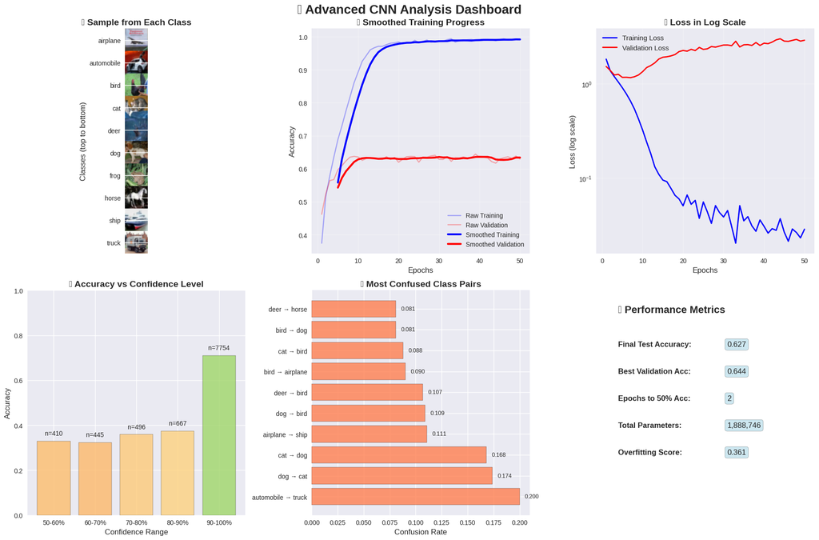

```python
# Model Insights and Feature Visualization
fig, axes = plt.subplots(2, 3, figsize=(18, 12))

# 1. Sample images from each class
ax = axes[0, 0]
sample_indices = []
for class_idx in range(10):
    class_indices = np.where(y_test.flatten() == class_idx)[0]
    sample_indices.append(class_indices[0])

# Create a grid of sample images
sample_grid = np.zeros((10*32, 32, 3), dtype=np.uint8)
for i, idx in enumerate(sample_indices):
    sample_grid[i*32:(i+1)*32, :, :] = x_test[idx]

ax.imshow(sample_grid)
ax.set_title('📸 Sample from Each Class', fontsize=14, fontweight='bold')
ax.set_ylabel('Classes (top to bottom)', fontsize=12)
ax.set_yticks(np.arange(10) * 32 + 16)
ax.set_yticklabels(class_names)
ax.set_xticks([])

# 2. Training Progress Over Time
ax = axes[0, 1]
smoothing_window = 5
smooth_train_acc = np.convolve(train_acc, np.ones(smoothing_window)/smoothing_window, mode='valid')
smooth_val_acc = np.convolve(val_acc, np.ones(smoothing_window)/smoothing_window, mode='valid')
smooth_epochs = epochs[smoothing_window-1:]

ax.plot(epochs, train_acc, alpha=0.3, color='blue', label='Raw Training')
ax.plot(epochs, val_acc, alpha=0.3, color='red', label='Raw Validation')
ax.plot(smooth_epochs, smooth_train_acc, linewidth=3, color='blue', label='Smoothed Training')
ax.plot(smooth_epochs, smooth_val_acc, linewidth=3, color='red', label='Smoothed Validation')
ax.set_title('📈 Smoothed Training Progress', fontsize=14, fontweight='bold')
ax.set_xlabel('Epochs', fontsize=12)
ax.set_ylabel('Accuracy', fontsize=12)
ax.legend(fontsize=10)
ax.grid(True, alpha=0.3)

# 3. Loss Landscape
ax = axes[0, 2]
ax.semilogy(epochs, train_loss, 'b-', linewidth=2, label='Training Loss')
ax.semilogy(epochs, val_loss, 'r-', linewidth=2, label='Validation Loss')
ax.set_title('📉 Loss in Log Scale', fontsize=14, fontweight='bold')
ax.set_xlabel('Epochs', fontsize=12)
ax.set_ylabel('Loss (log scale)', fontsize=12)
ax.legend(fontsize=11)
ax.grid(True, alpha=0.3)

# 4. Prediction Certainty Analysis
ax = axes[1, 0]
certainty_bins = [0.5, 0.6, 0.7, 0.8, 0.9, 1.0]
certainty_labels = ['50-60%', '60-70%', '70-80%', '80-90%', '90-100%']
certainty_counts = []
certainty_accuracy = []

for i in range(len(certainty_bins)-1):
    mask = (all_confidences >= certainty_bins[i]) & (all_confidences < certainty_bins[i+1])
    count = np.sum(mask)
    if count > 0:
        accuracy = np.mean(correct_predictions[mask])
    else:
        accuracy = 0
    certainty_counts.append(count)
    certainty_accuracy.append(accuracy)

# Handle the last bin (90-100%)
mask = all_confidences >= certainty_bins[-2]
certainty_counts[-1] = np.sum(mask)
if certainty_counts[-1] > 0:
    certainty_accuracy[-1] = np.mean(correct_predictions[mask])

bars = ax.bar(certainty_labels, certainty_accuracy,
              color=plt.cm.RdYlGn(np.array(certainty_accuracy)),
              alpha=0.8, edgecolor='black')
ax.set_title('🎯 Accuracy vs Confidence Level', fontsize=14, fontweight='bold')
ax.set_xlabel('Confidence Range', fontsize=12)
ax.set_ylabel('Accuracy', fontsize=12)
ax.set_ylim(0, 1)

# Add count labels on bars
for bar, count in zip(bars, certainty_counts):
    height = bar.get_height()
    ax.text(bar.get_x() + bar.get_width()/2., height + 0.02,
            f'n={count}', ha='center', va='bottom', fontsize=10)

# 5. Most Confused Classes
ax = axes[1, 1]
# Find most confused pairs
cm_norm = cm.astype('float') / cm.sum(axis=1)[:, np.newaxis]
np.fill_diagonal(cm_norm, 0)  # Remove diagonal
most_confused = np.unravel_index(np.argmax(cm_norm), cm_norm.shape)

confusion_pairs = []
confusion_rates = []
for i in range(10):
    for j in range(10):
        if i != j and cm_norm[i, j] > 0.05:  # More than 5% confusion
            confusion_pairs.append(f"{class_names[i]} → {class_names[j]}")
            confusion_rates.append(cm_norm[i, j])

if confusion_pairs:
    # Sort by confusion rate
    sorted_pairs = sorted(zip(confusion_pairs, confusion_rates), key=lambda x: x[1], reverse=True)
    pairs, rates = zip(*sorted_pairs[:10])  # Top 10 confusions

    bars = ax.barh(range(len(pairs)), rates, color='coral', alpha=0.8, edgecolor='black')
    ax.set_yticks(range(len(pairs)))
    ax.set_yticklabels(pairs, fontsize=10)
    ax.set_xlabel('Confusion Rate', fontsize=12)
    ax.set_title('🔀 Most Confused Class Pairs', fontsize=14, fontweight='bold')

    # Add value labels
    for bar, rate in zip(bars, rates):
        width = bar.get_width()
        ax.text(width + 0.005, bar.get_y() + bar.get_height()/2.,
                f'{rate:.3f}', ha='left', va='center', fontsize=9)

# 6. Training Efficiency Metrics
ax = axes[1, 2]
# Calculate training efficiency metrics
epochs_to_convergence = None
for i, val_acc_val in enumerate(val_acc):
    if val_acc_val > 0.5:  # 50% accuracy threshold
        epochs_to_convergence = i + 1
        break

metrics = {
    'Final Test Accuracy': f'{test_accuracy:.3f}',
    'Best Validation Acc': f'{max(val_acc):.3f}',
    'Epochs to 50% Acc': f'{epochs_to_convergence or "N/A"}',
    'Total Parameters': f'{model.count_params():,}',
    'Overfitting Score': f'{max(0, final_train_acc - final_val_acc):.3f}'
}

ax.axis('off')
ax.text(0.1, 0.9, '📊 Performance Metrics', fontsize=16, fontweight='bold', transform=ax.transAxes)

y_pos = 0.75
for metric, value in metrics.items():
    ax.text(0.1, y_pos, f'{metric}:', fontsize=12, fontweight='bold', transform=ax.transAxes)
    ax.text(0.6, y_pos, value, fontsize=12, transform=ax.transAxes,
            bbox=dict(boxstyle="round,pad=0.3", facecolor="lightblue", alpha=0.6))
    y_pos -= 0.12

plt.suptitle('🧠 Advanced CNN Analysis Dashboard', fontsize=20, fontweight='bold', y=0.98)
plt.tight_layout()
plt.show()
```

## 🎨 Enhanced Visualization Summary

The enhanced graphs provide comprehensive insights into your CNN model's performance:

### 📈 **Training Analysis Dashboard**

- **Loss & Accuracy Curves**: Shows training progression with filled areas for better visual impact
- **Overfitting Analysis**: Tracks the gap between training and validation accuracy
- **Training Summary**: Key metrics displayed in an organized format

### 🔍 **Performance Analysis**

- **Confusion Matrix**: Heatmap showing which classes are confused with each other
- **Per-Class Accuracy**: Bar chart revealing which objects are hardest to classify
- **Confidence Distribution**: Histogram comparing confidence scores for correct vs incorrect predictions
- **Model Architecture**: Visual summary of your CNN structure

### 🧠 **Advanced Insights Dashboard**

- **Sample Images**: Representative image from each CIFAR-10 class
- **Smoothed Progress**: Noise-reduced training curves for clearer trends
- **Log-Scale Loss**: Better visualization of loss convergence
- **Confidence vs Accuracy**: How prediction confidence correlates with correctness
- **Most Confused Pairs**: Which classes your model struggles to distinguish
- **Performance Metrics**: Comprehensive summary of key indicators